# cintyakristianto

```python
import pandas as pd
```

```python
import numpy as np
```

```python
import matplotlib.pyplot as plt
```

1. Deskripsikan variabel yang ada di dalam data !

jawaban : dalam data movies memiliki 20 variabel yang terdiri dari :

- Budget: merupakan pengeluaran movies di tiap bulan
- Genres: merupakan kategori movies
- HomePage:merupakan alamat website dalam movies
- id : movies memiliki id untuk memudahkan dalam pencarian movies berdasarkan angka
- keywords:memudahkan dalam pencarian movies dalam bentuk dictionary
- original_language: bahasa asli dalam film tanpa substitle atau multi bahasa
- original_title: judul asli dengan adanya hak paten
- overview: sinopsis dalam movies
- popularity: jumlah populiratas movies yang banyak di tayang
- production_companies:perusahaan pembuatan dan pengeluaran film
- production_countries: negara yang mengeluarkan film
- release_date: tanggal pengeluaran film
- revenue: total pendapatan dari hasil penayangan film
- runtime: durasi film yang di putar
- spoken_languages: percakapan film yang di gunaan
- status: status pengeluaran film
- tagline: slogan dalam film atau teks pendek yang berfungsi untuk memperjelas pemikiran, atau dirancang dengan efek dramatis.
- title: judul film
- vote_average: rata rata rating film
- vote_count:menghitung keselurahan rating

## yang merupakan numerik

- Budget(Diskret)->karena budget dihitung
- id(Diskret)->id di hitung berdasarkan kode film
- popularity(Diskret)-> di hitung jumlah penayangan
- Reveneu(Diskret)->pendapatan di hitung berdarsarakan jumlah penonton tiap melakukan penayangan
- Runtime(Continious)->lama film di hitung dalam menit
- vote_average(Continious)->perhitungan rata- rata vote menggunakan presentase
- vote_count(Diskret)->menghitung keseluruhan dalam melakukan vote

### yang merupakan categorical

- genres(Reguler Categorical)->film terbagi menjadi beberapa kategori film
- homepages(Reguler Categorical)->link hanya dapat di akses sesuai yang di berikan
- keywords(Reguler categorical)->memiliki keyword untuk mencari data yang dicari
- original_language(Reguler Categorical)->memiliki satu bahasa saja
- original_title(Reguler Categorical)->memiliki judul asli tanpa copyright
- overview(Reguler Categorical)->film memiliki sinopsis sesuai judul
- production_companies(Reguler Categorical)->berdasarkan perusahaan
- production_countries(Reguler Categorical)->berdasarkan negara
- release_date(Reguler Categorical)->berdasarkan tangal
- spoken_language(Regular Categorical)->percakapan bahasa berdasarkan jenis bahasa
- status(Regular Categorical)->status release
- tagline(Regular Categorical)->slogan tiap film memiliki ciri khas masing masing
- title(Regular Categorical)->tiap film punya judul berbeda

```python
movies=pd.read_csv('tmdb_5000_movies.csv')
movies.head()
```

|  | budget | genres | homepage | id | keywords | original_language | original_title | overview | popularity | production_companies | production_countries | release_date | revenue | runtime | spoken_languages | status | tagline | title | vote_average | vote_count |
| --- | --- | --- | --- | --- | --- | --- | --- | --- | --- | --- | --- | --- | --- | --- | --- | --- | --- | --- | --- | --- |
| 0 | 237000000 | [{"id": 28, "name": "Action"}, {"id": 12, "nam... | http://www.avatarmovie.com/ | 19995 | [{"id": 1463, "name": "culture clash"}, {"id":... | en | Avatar | In the 22nd century, a paraplegic Marine is di... | 150.437577 | [{"name": "Ingenious Film Partners", "id": 289... | [{"iso_3166_1": "US", "name": "United States o... | 2009-12-10 | 2787965087 | 162.0 | [{"iso_639_1": "en", "name": "English"}, {"iso... | Released | Enter the World of Pandora. | Avatar | 7.2 | 11800 |
| 1 | 300000000 | [{"id": 12, "name": "Adventure"}, {"id": 14, "... | http://disney.go.com/disneypictures/pirates/ | 285 | [{"id": 270, "name": "ocean"}, {"id": 726, "na... | en | Pirates of the Caribbean: At World's End | Captain Barbossa, long believed to be dead, ha... | 139.082615 | [{"name": "Walt Disney Pictures", "id": 2}, {"... | [{"iso_3166_1": "US", "name": "United States o... | 2007-05-19 | 961000000 | 169.0 | [{"iso_639_1": "en", "name": "English"}] | Released | At the end of the world, the adventure begins. | Pirates of the Caribbean: At World's End | 6.9 | 4500 |
| 2 | 245000000 | [{"id": 28, "name": "Action"}, {"id": 12, "nam... | http://www.sonypictures.com/movies/spectre/ | 206647 | [{"id": 470, "name": "spy"}, {"id": 818, "name... | en | Spectre | A cryptic message from Bond’s past sends him o... | 107.376788 | [{"name": "Columbia Pictures", "id": 5}, {"nam... | [{"iso_3166_1": "GB", "name": "United Kingdom"... | 2015-10-26 | 880674609 | 148.0 | [{"iso_639_1": "fr", "name": "Fran\u00e7ais"},... | Released | A Plan No One Escapes | Spectre | 6.3 | 4466 |
| 3 | 250000000 | [{"id": 28, "name": "Action"}, {"id": 80, "nam... | http://www.thedarkknightrises.com/ | 49026 | [{"id": 849, "name": "dc comics"}, {"id": 853,... | en | The Dark Knight Rises | Following the death of District Attorney Harve... | 112.312950 | [{"name": "Legendary Pictures", "id": 923}, {"... | [{"iso_3166_1": "US", "name": "United States o... | 2012-07-16 | 1084939099 | 165.0 | [{"iso_639_1": "en", "name": "English"}] | Released | The Legend Ends | The Dark Knight Rises | 7.6 | 9106 |
| 4 | 260000000 | [{"id": 28, "name": "Action"}, {"id": 12, "nam... | http://movies.disney.com/john-carter | 49529 | [{"id": 818, "name": "based on novel"}, {"id":... | en | John Carter | John Carter is a war-weary, former military ca... | 43.926995 | [{"name": "Walt Disney Pictures", "id": 2}] | [{"iso_3166_1": "US", "name": "United States o... | 2012-03-07 | 284139100 | 132.0 | [{"iso_639_1": "en", "name": "English"}] | Released | Lost in our world, found in another. | John Carter | 6.1 | 2124 |

```python
movies.info()
```

```
<class 'pandas.core.frame.DataFrame'>
RangeIndex: 4803 entries, 0 to 4802
Data columns (total 20 columns):
budget                  4803 non-null int64
genres                  4803 non-null object
homepage                1712 non-null object
id                      4803 non-null int64
keywords                4803 non-null object
original_language       4803 non-null object
original_title          4803 non-null object
overview                4800 non-null object
popularity              4803 non-null float64
production_companies    4803 non-null object
production_countries    4803 non-null object
release_date            4802 non-null object
revenue                 4803 non-null int64
runtime                 4801 non-null float64
spoken_languages        4803 non-null object
status                  4803 non-null object
tagline                 3959 non-null object
title                   4803 non-null object
vote_average            4803 non-null float64
vote_count              4803 non-null int64
dtypes: float64(3), int64(4), object(13)
memory usage: 750.6+ KB
```

# =====================================================================================================================

1. a)identifikasi bila ada nilai yang hilang.

```python
movies.isnull().sum()
```

```
budget                     0
genres                     0
homepage                3091
id                         0
keywords                   0
original_language          0
original_title             0
overview                   3
popularity                 0
production_companies       0
production_countries       0
release_date               1
revenue                    0
runtime                    2
spoken_languages           0
status                     0
tagline                  844
title                      0
vote_average               0
vote_count                 0
dtype: int64
```

## data yang hilang:

2 b.)lakukan dropna(),Berapa yang di drop!

```python
drop_movies=movies.dropna(axis = 0, how ='any')
print("panjang data lama:"+ str(len(movies)))
print("panjang data baru :"+str(len(drop_movies)))
```

```
panjang data lama:4803
panjang data baru :1493
```

```python
drop_movies.info()
```

```
<class 'pandas.core.frame.DataFrame'>
Int64Index: 1493 entries, 0 to 4801
Data columns (total 20 columns):
budget                  1493 non-null int64
genres                  1493 non-null object
homepage                1493 non-null object
id                      1493 non-null int64
keywords                1493 non-null object
original_language       1493 non-null object
original_title          1493 non-null object
overview                1493 non-null object
popularity              1493 non-null float64
production_companies    1493 non-null object
production_countries    1493 non-null object
release_date            1493 non-null object
revenue                 1493 non-null int64
runtime                 1493 non-null float64
spoken_languages        1493 non-null object
status                  1493 non-null object
tagline                 1493 non-null object
title                   1493 non-null object
vote_average            1493 non-null float64
vote_count              1493 non-null int64
dtypes: float64(3), int64(4), object(13)
memory usage: 244.9+ KB
```

awalnya mempunyai data sekitar 4803 kemudian di drop NA menjadi 1493, kemungkinan data yang di miliki sangat banyak memiliki data NA sekitar 3310 yang di drop

# ======================================================================================================================

1. jelaskan hasil stastitik deskriptif untuk variabel bertipe numerik !

```python
drop_movies.head()
```

|  | budget | genres | homepage | id | keywords | original_language | original_title | overview | popularity | production_companies | production_countries | release_date | revenue | runtime | spoken_languages | status | tagline | title | vote_average | vote_count |
| --- | --- | --- | --- | --- | --- | --- | --- | --- | --- | --- | --- | --- | --- | --- | --- | --- | --- | --- | --- | --- |
| 0 | 237000000 | [{"id": 28, "name": "Action"}, {"id": 12, "nam... | http://www.avatarmovie.com/ | 19995 | [{"id": 1463, "name": "culture clash"}, {"id":... | en | Avatar | In the 22nd century, a paraplegic Marine is di... | 150.437577 | [{"name": "Ingenious Film Partners", "id": 289... | [{"iso_3166_1": "US", "name": "United States o... | 2009-12-10 | 2787965087 | 162.0 | [{"iso_639_1": "en", "name": "English"}, {"iso... | Released | Enter the World of Pandora. | Avatar | 7.2 | 11800 |
| 1 | 300000000 | [{"id": 12, "name": "Adventure"}, {"id": 14, "... | http://disney.go.com/disneypictures/pirates/ | 285 | [{"id": 270, "name": "ocean"}, {"id": 726, "na... | en | Pirates of the Caribbean: At World's End | Captain Barbossa, long believed to be dead, ha... | 139.082615 | [{"name": "Walt Disney Pictures", "id": 2}, {"... | [{"iso_3166_1": "US", "name": "United States o... | 2007-05-19 | 961000000 | 169.0 | [{"iso_639_1": "en", "name": "English"}] | Released | At the end of the world, the adventure begins. | Pirates of the Caribbean: At World's End | 6.9 | 4500 |
| 2 | 245000000 | [{"id": 28, "name": "Action"}, {"id": 12, "nam... | http://www.sonypictures.com/movies/spectre/ | 206647 | [{"id": 470, "name": "spy"}, {"id": 818, "name... | en | Spectre | A cryptic message from Bond’s past sends him o... | 107.376788 | [{"name": "Columbia Pictures", "id": 5}, {"nam... | [{"iso_3166_1": "GB", "name": "United Kingdom"... | 2015-10-26 | 880674609 | 148.0 | [{"iso_639_1": "fr", "name": "Fran\u00e7ais"},... | Released | A Plan No One Escapes | Spectre | 6.3 | 4466 |
| 3 | 250000000 | [{"id": 28, "name": "Action"}, {"id": 80, "nam... | http://www.thedarkknightrises.com/ | 49026 | [{"id": 849, "name": "dc comics"}, {"id": 853,... | en | The Dark Knight Rises | Following the death of District Attorney Harve... | 112.312950 | [{"name": "Legendary Pictures", "id": 923}, {"... | [{"iso_3166_1": "US", "name": "United States o... | 2012-07-16 | 1084939099 | 165.0 | [{"iso_639_1": "en", "name": "English"}] | Released | The Legend Ends | The Dark Knight Rises | 7.6 | 9106 |
| 4 | 260000000 | [{"id": 28, "name": "Action"}, {"id": 12, "nam... | http://movies.disney.com/john-carter | 49529 | [{"id": 818, "name": "based on novel"}, {"id":... | en | John Carter | John Carter is a war-weary, former military ca... | 43.926995 | [{"name": "Walt Disney Pictures", "id": 2}] | [{"iso_3166_1": "US", "name": "United States o... | 2012-03-07 | 284139100 | 132.0 | [{"iso_639_1": "en", "name": "English"}] | Released | Lost in our world, found in another. | John Carter | 6.1 | 2124 |

```python
drop_movies.info()
```

```
<class 'pandas.core.frame.DataFrame'>
Int64Index: 1493 entries, 0 to 4801
Data columns (total 20 columns):
budget                  1493 non-null int64
genres                  1493 non-null object
homepage                1493 non-null object
id                      1493 non-null int64
keywords                1493 non-null object
original_language       1493 non-null object
original_title          1493 non-null object
overview                1493 non-null object
popularity              1493 non-null float64
production_companies    1493 non-null object
production_countries    1493 non-null object
release_date            1493 non-null object
revenue                 1493 non-null int64
runtime                 1493 non-null float64
spoken_languages        1493 non-null object
status                  1493 non-null object
tagline                 1493 non-null object
title                   1493 non-null object
vote_average            1493 non-null float64
vote_count              1493 non-null int64
dtypes: float64(3), int64(4), object(13)
memory usage: 244.9+ KB
```

```python
df=pd.DataFrame(drop_movies,columns=['budget','id','popularity','revenue','runtime','vote_average','vote_count'])
```

```python
df['budget'].describe()
```

```
count    1.493000e+03
mean     4.589534e+07
std      5.369219e+07
min      0.000000e+00
25%      7.500000e+06
50%      2.700000e+07
75%      6.300000e+07
max      3.800000e+08
Name: budget, dtype: float64
```

dari hasil tersebut bahwa *budget* terdiri sekitar dari 1,493 data dengan rata-rata 4,589 ,standar deviasi 5,369,nilai minimunnya 0, nilai kuartil1 7,5 , nilai kuartil2 (median) 2,7, nilai kuartil3 6,3, nilai maksimu 3,8

```python
df['id'].describe()
```

```
count      1493.000000
mean      65498.552579
std       89841.824027
min          11.000000
25%        8090.000000
50%       26320.000000
75%       76341.000000
max      426469.000000
Name: id, dtype: float64
```

dari hasil tersebut *id* terdiri 1493 data , dengan rata-rata 65498, standar deviasi 89841, nilai minimunnya 11, nilai kuartil1 8090 , nilai kuartil2 26320,nilai kuartil3 76341,nilai maksimum 426469

```python
df['popularity'].describe()
```

```
count    1493.000000
mean       35.749280
std        48.207525
min         0.023681
25%        11.624230
50%        25.281197
75%        45.149948
max       875.581305
Name: popularity, dtype: float64
```

dari hasil tersebut *popularity* terdiri 1493 data , dengan rata-rata 35, standar deviasi 48, nilai minimunnya 0, nilai kuartil1 11 , nilai kuartil2 25,nilai kuartil3 45,nilai maksimum 875

```python
df['runtime'].describe()
```

```
count    1493.000000
mean      108.657736
std        19.378758
min         0.000000
25%        95.000000
50%       106.000000
75%       120.000000
max       201.000000
Name: runtime, dtype: float64
```

dari hasil tersebut *runtime* terdiri 1493 data , dengan rata-rata 108.657736, standar deviasi 19.378758, nilai minimunnya 0, nilai kuartil1 95, nilai kuartil2 106,nilai kuartil3 120,nilai maksimum 201

```python
df['vote_average'].describe()
```

```
count    1493.000000
mean        6.272873
std         0.970480
min         0.000000
25%         5.800000
50%         6.300000
75%         6.900000
max         8.400000
Name: vote_average, dtype: float64
```

dari hasil tersebut *vote_average* terdiri 1493 data , dengan rata-rata 6.272, standar deviasi 0,97, nilai minimunnya 0, nilai kuartil1 5.8, nilai kuartil2 6.3,nilai kuartil3 6.9,nilai maksimum 8.4

```python
df['vote_count'].describe()
```

```
count     1493.000000
mean      1323.557267
std       1792.459010
min          0.000000
25%        207.000000
50%        616.000000
75%       1652.000000
max      13752.000000
Name: vote_count, dtype: float64
```

dari hasil tersebut *vote_count* terdiri 1493 data , dengan rata-rata 1323, standar deviasi 1792, nilai minimunnya 0, nilai kuartil1 207, nilai kuartil2 616,nilai kuartil3 1652,nilai maksimum 13752

```python
df['revenue'].describe()
```

```
count    1.493000e+03
mean     1.550083e+08
std      2.408712e+08
min      0.000000e+00
25%      9.455232e+06
50%      6.254895e+07
75%      1.860537e+08
max      2.787965e+09
Name: revenue, dtype: float64
```

dari hasil tersebut *revenue* terdiri 1,493 data , dengan rata-rata 1,55, standar deviasi 2,408, nilai minimunnya 0, nilai kuartil1 9,455, nilai kuartil2 6.254,nilai kuartil3 1.860,nilai maksimum 2.787

# =====================================================================================================================

1. pilih 3 hubungan yang ada kaitan budget, budget-populirity,pakai scaterrplott dan lakukan analisa

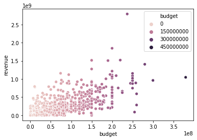

```python
import seaborn as sns

sns.scatterplot(x='budget', y='revenue', hue='budget', data=drop_movies)
```

evaluasi the relationship *budget-reveneu*

- direction:positive
- shape:linear
- strength: strong
- memiliki outliers

hubungannya dengan budget-revenue yaitu budget yang di keluarkan besar tetapi revenue yang di dapatkan lebih besar sehingga pendapatan perilisan film mengalami keuntungan

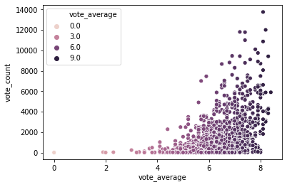

```python
import seaborn as sns

sns.scatterplot(x='vote_average', y='vote_count', hue='vote_average', data=drop_movies)
```

evaluasi the relationship *vote_average-vote_count*

- direction:positive
- shape:curved
- strength: strong
- memiliki outliers

hubungannya dengan vote_average-vote_count adalah semakin besar vote_averagenya maka jumlah vote_countnya tinggi

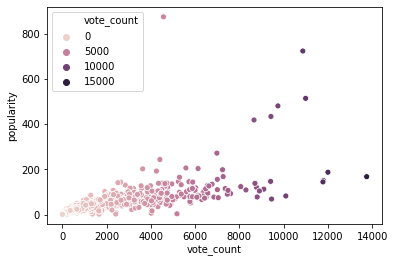

```python
import seaborn as sns

sns.scatterplot(x='vote_count', y='popularity', hue='vote_count', data=drop_movies)
```

evaluasi the relationship *vote_count-popularity*

- direction:positive
- shape:linear
- strength: strong
- memiliki outliers

hubungannya dengan vote_count-popularity yaitu semakin banyak vote_countnya makan popularitynya makin tinggi

# ======================================================================================================================

1. buatkan print 20 film dengan budget,reveneu,vote tertinggi.lihat ada iris apa dan analisis.

```python
best_budget = drop_movies.nlargest(20,'budget')
best_budget
```

|  | budget | genres | homepage | id | keywords | original_language | original_title | overview | popularity | production_companies | production_countries | release_date | revenue | runtime | spoken_languages | status | tagline | title | vote_average | vote_count |
| --- | --- | --- | --- | --- | --- | --- | --- | --- | --- | --- | --- | --- | --- | --- | --- | --- | --- | --- | --- | --- |
| 17 | 380000000 | [{"id": 12, "name": "Adventure"}, {"id": 28, "... | http://disney.go.com/pirates/index-on-stranger... | 1865 | [{"id": 658, "name": "sea"}, {"id": 1316, "nam... | en | Pirates of the Caribbean: On Stranger Tides | Captain Jack Sparrow crosses paths with a woma... | 135.413856 | [{"name": "Walt Disney Pictures", "id": 2}, {"... | [{"iso_3166_1": "US", "name": "United States o... | 2011-05-14 | 1045713802 | 136.0 | [{"iso_639_1": "en", "name": "English"}, {"iso... | Released | Live Forever Or Die Trying. | Pirates of the Caribbean: On Stranger Tides | 6.4 | 4948 |
| 1 | 300000000 | [{"id": 12, "name": "Adventure"}, {"id": 14, "... | http://disney.go.com/disneypictures/pirates/ | 285 | [{"id": 270, "name": "ocean"}, {"id": 726, "na... | en | Pirates of the Caribbean: At World's End | Captain Barbossa, long believed to be dead, ha... | 139.082615 | [{"name": "Walt Disney Pictures", "id": 2}, {"... | [{"iso_3166_1": "US", "name": "United States o... | 2007-05-19 | 961000000 | 169.0 | [{"iso_639_1": "en", "name": "English"}] | Released | At the end of the world, the adventure begins. | Pirates of the Caribbean: At World's End | 6.9 | 4500 |
| 7 | 280000000 | [{"id": 28, "name": "Action"}, {"id": 12, "nam... | http://marvel.com/movies/movie/193/avengers_ag... | 99861 | [{"id": 8828, "name": "marvel comic"}, {"id": ... | en | Avengers: Age of Ultron | When Tony Stark tries to jumpstart a dormant p... | 134.279229 | [{"name": "Marvel Studios", "id": 420}, {"name... | [{"iso_3166_1": "US", "name": "United States o... | 2015-04-22 | 1405403694 | 141.0 | [{"iso_639_1": "en", "name": "English"}] | Released | A New Age Has Come. | Avengers: Age of Ultron | 7.3 | 6767 |
| 4 | 260000000 | [{"id": 28, "name": "Action"}, {"id": 12, "nam... | http://movies.disney.com/john-carter | 49529 | [{"id": 818, "name": "based on novel"}, {"id":... | en | John Carter | John Carter is a war-weary, former military ca... | 43.926995 | [{"name": "Walt Disney Pictures", "id": 2}] | [{"iso_3166_1": "US", "name": "United States o... | 2012-03-07 | 284139100 | 132.0 | [{"iso_639_1": "en", "name": "English"}] | Released | Lost in our world, found in another. | John Carter | 6.1 | 2124 |
| 6 | 260000000 | [{"id": 16, "name": "Animation"}, {"id": 10751... | http://disney.go.com/disneypictures/tangled/ | 38757 | [{"id": 1562, "name": "hostage"}, {"id": 2343,... | en | Tangled | When the kingdom's most wanted-and most charmi... | 48.681969 | [{"name": "Walt Disney Pictures", "id": 2}, {"... | [{"iso_3166_1": "US", "name": "United States o... | 2010-11-24 | 591794936 | 100.0 | [{"iso_639_1": "en", "name": "English"}] | Released | They're taking adventure to new lengths. | Tangled | 7.4 | 3330 |
| 5 | 258000000 | [{"id": 14, "name": "Fantasy"}, {"id": 28, "na... | http://www.sonypictures.com/movies/spider-man3/ | 559 | [{"id": 851, "name": "dual identity"}, {"id": ... | en | Spider-Man 3 | The seemingly invincible Spider-Man goes up ag... | 115.699814 | [{"name": "Columbia Pictures", "id": 5}, {"nam... | [{"iso_3166_1": "US", "name": "United States o... | 2007-05-01 | 890871626 | 139.0 | [{"iso_639_1": "en", "name": "English"}, {"iso... | Released | The battle within. | Spider-Man 3 | 5.9 | 3576 |
| 13 | 255000000 | [{"id": 28, "name": "Action"}, {"id": 12, "nam... | http://disney.go.com/the-lone-ranger/ | 57201 | [{"id": 1556, "name": "texas"}, {"id": 2673, "... | en | The Lone Ranger | The Texas Rangers chase down a gang of outlaws... | 49.046956 | [{"name": "Walt Disney Pictures", "id": 2}, {"... | [{"iso_3166_1": "US", "name": "United States o... | 2013-07-03 | 89289910 | 149.0 | [{"iso_639_1": "en", "name": "English"}] | Released | Never Take Off the Mask | The Lone Ranger | 5.9 | 2311 |
| 3 | 250000000 | [{"id": 28, "name": "Action"}, {"id": 80, "nam... | http://www.thedarkknightrises.com/ | 49026 | [{"id": 849, "name": "dc comics"}, {"id": 853,... | en | The Dark Knight Rises | Following the death of District Attorney Harve... | 112.312950 | [{"name": "Legendary Pictures", "id": 923}, {"... | [{"iso_3166_1": "US", "name": "United States o... | 2012-07-16 | 1084939099 | 165.0 | [{"iso_639_1": "en", "name": "English"}] | Released | The Legend Ends | The Dark Knight Rises | 7.6 | 9106 |
| 8 | 250000000 | [{"id": 12, "name": "Adventure"}, {"id": 14, "... | http://harrypotter.warnerbros.com/harrypottera... | 767 | [{"id": 616, "name": "witch"}, {"id": 2343, "n... | en | Harry Potter and the Half-Blood Prince | As Harry begins his sixth year at Hogwarts, he... | 98.885637 | [{"name": "Warner Bros.", "id": 6194}, {"name"... | [{"iso_3166_1": "GB", "name": "United Kingdom"... | 2009-07-07 | 933959197 | 153.0 | [{"iso_639_1": "en", "name": "English"}] | Released | Dark Secrets Revealed | Harry Potter and the Half-Blood Prince | 7.4 | 5293 |
| 9 | 250000000 | [{"id": 28, "name": "Action"}, {"id": 12, "nam... | http://www.batmanvsupermandawnofjustice.com/ | 209112 | [{"id": 849, "name": "dc comics"}, {"id": 7002... | en | Batman v Superman: Dawn of Justice | Fearing the actions of a god-like Super Hero l... | 155.790452 | [{"name": "DC Comics", "id": 429}, {"name": "A... | [{"iso_3166_1": "US", "name": "United States o... | 2016-03-23 | 873260194 | 151.0 | [{"iso_639_1": "en", "name": "English"}] | Released | Justice or revenge | Batman v Superman: Dawn of Justice | 5.7 | 7004 |
| 19 | 250000000 | [{"id": 28, "name": "Action"}, {"id": 12, "nam... | http://www.thehobbit.com/ | 122917 | [{"id": 417, "name": "corruption"}, {"id": 603... | en | The Hobbit: The Battle of the Five Armies | Immediately after the events of The Desolation... | 120.965743 | [{"name": "WingNut Films", "id": 11}, {"name":... | [{"iso_3166_1": "NZ", "name": "New Zealand"}, ... | 2014-12-10 | 956019788 | 144.0 | [{"iso_639_1": "en", "name": "English"}] | Released | Witness the defining chapter of the Middle-Ear... | The Hobbit: The Battle of the Five Armies | 7.1 | 4760 |
| 22 | 250000000 | [{"id": 12, "name": "Adventure"}, {"id": 14, "... | http://www.thehobbit.com/ | 57158 | [{"id": 603, "name": "elves"}, {"id": 604, "na... | en | The Hobbit: The Desolation of Smaug | The Dwarves, Bilbo and Gandalf have successful... | 94.370564 | [{"name": "WingNut Films", "id": 11}, {"name":... | [{"iso_3166_1": "NZ", "name": "New Zealand"}, ... | 2013-12-11 | 958400000 | 161.0 | [{"iso_639_1": "en", "name": "English"}] | Released | Beyond darkness... beyond desolation... lies t... | The Hobbit: The Desolation of Smaug | 7.6 | 4524 |
| 26 | 250000000 | [{"id": 12, "name": "Adventure"}, {"id": 28, "... | http://marvel.com/captainamericapremiere | 271110 | [{"id": 393, "name": "civil war"}, {"id": 6091... | en | Captain America: Civil War | Following the events of Age of Ultron, the col... | 198.372395 | [{"name": "Studio Babelsberg", "id": 264}, {"n... | [{"iso_3166_1": "US", "name": "United States o... | 2016-04-27 | 1153304495 | 147.0 | [{"iso_639_1": "ro", "name": "Rom\u00e2n\u0103... | Released | Divided We Fall | Captain America: Civil War | 7.1 | 7241 |
| 46 | 250000000 | [{"id": 28, "name": "Action"}, {"id": 12, "nam... | http://www.x-menmovies.com/ | 127585 | [{"id": 1228, "name": "1970s"}, {"id": 1852, "... | en | X-Men: Days of Future Past | The ultimate X-Men ensemble fights a war for t... | 118.078691 | [{"name": "Twentieth Century Fox Film Corporat... | [{"iso_3166_1": "GB", "name": "United Kingdom"... | 2014-05-15 | 747862775 | 131.0 | [{"iso_639_1": "en", "name": "English"}] | Released | To save the future, they must alter the past | X-Men: Days of Future Past | 7.5 | 6032 |
| 98 | 250000000 | [{"id": 12, "name": "Adventure"}, {"id": 14, "... | http://www.thehobbit.com/ | 49051 | [{"id": 483, "name": "riddle"}, {"id": 603, "n... | en | The Hobbit: An Unexpected Journey | Bilbo Baggins, a hobbit enjoying his quiet lif... | 108.849621 | [{"name": "WingNut Films", "id": 11}, {"name":... | [{"iso_3166_1": "NZ", "name": "New Zealand"}, ... | 2012-11-26 | 1021103568 | 169.0 | [{"iso_639_1": "en", "name": "English"}] | Released | From the smallest beginnings come the greatest... | The Hobbit: An Unexpected Journey | 7.0 | 8297 |
| 2 | 245000000 | [{"id": 28, "name": "Action"}, {"id": 12, "nam... | http://www.sonypictures.com/movies/spectre/ | 206647 | [{"id": 470, "name": "spy"}, {"id": 818, "name... | en | Spectre | A cryptic message from Bond’s past sends him o... | 107.376788 | [{"name": "Columbia Pictures", "id": 5}, {"nam... | [{"iso_3166_1": "GB", "name": "United Kingdom"... | 2015-10-26 | 880674609 | 148.0 | [{"iso_639_1": "fr", "name": "Fran\u00e7ais"},... | Released | A Plan No One Escapes | Spectre | 6.3 | 4466 |
| 0 | 237000000 | [{"id": 28, "name": "Action"}, {"id": 12, "nam... | http://www.avatarmovie.com/ | 19995 | [{"id": 1463, "name": "culture clash"}, {"id":... | en | Avatar | In the 22nd century, a paraplegic Marine is di... | 150.437577 | [{"name": "Ingenious Film Partners", "id": 289... | [{"iso_3166_1": "US", "name": "United States o... | 2009-12-10 | 2787965087 | 162.0 | [{"iso_639_1": "en", "name": "English"}, {"iso... | Released | Enter the World of Pandora. | Avatar | 7.2 | 11800 |
| 14 | 225000000 | [{"id": 28, "name": "Action"}, {"id": 12, "nam... | http://www.manofsteel.com/ | 49521 | [{"id": 83, "name": "saving the world"}, {"id"... | en | Man of Steel | A young boy learns that he has extraordinary p... | 99.398009 | [{"name": "Legendary Pictures", "id": 923}, {"... | [{"iso_3166_1": "GB", "name": "United Kingdom"... | 2013-06-12 | 662845518 | 143.0 | [{"iso_639_1": "en", "name": "English"}] | Released | You will believe that a man can fly. | Man of Steel | 6.5 | 6359 |
| 18 | 225000000 | [{"id": 28, "name": "Action"}, {"id": 35, "nam... | http://www.sonypictures.com/movies/meninblack3/ | 41154 | [{"id": 4379, "name": "time travel"}, {"id": 5... | en | Men in Black 3 | Agents J (Will Smith) and K (Tommy Lee Jones) ... | 52.035179 | [{"name": "Amblin Entertainment", "id": 56}, {... | [{"iso_3166_1": "US", "name": "United States o... | 2012-05-23 | 624026776 | 106.0 | [{"iso_639_1": "en", "name": "English"}] | Released | They are back... in time. | Men in Black 3 | 6.2 | 4160 |
| 16 | 220000000 | [{"id": 878, "name": "Science Fiction"}, {"id"... | http://marvel.com/avengers_movie/ | 24428 | [{"id": 242, "name": "new york"}, {"id": 5539,... | en | The Avengers | When an unexpected enemy emerges and threatens... | 144.448633 | [{"name": "Paramount Pictures", "id": 4}, {"na... | [{"iso_3166_1": "US", "name": "United States o... | 2012-04-25 | 1519557910 | 143.0 | [{"iso_639_1": "en", "name": "English"}] | Released | Some assembly required. | The Avengers | 7.4 | 11776 |

```python
best_revenue = drop_movies.nlargest(20,'revenue')
best_revenue
```

|  | budget | genres | homepage | id | keywords | original_language | original_title | overview | popularity | production_companies | production_countries | release_date | revenue | runtime | spoken_languages | status | tagline | title | vote_average | vote_count |
| --- | --- | --- | --- | --- | --- | --- | --- | --- | --- | --- | --- | --- | --- | --- | --- | --- | --- | --- | --- | --- |
| 0 | 237000000 | [{"id": 28, "name": "Action"}, {"id": 12, "nam... | http://www.avatarmovie.com/ | 19995 | [{"id": 1463, "name": "culture clash"}, {"id":... | en | Avatar | In the 22nd century, a paraplegic Marine is di... | 150.437577 | [{"name": "Ingenious Film Partners", "id": 289... | [{"iso_3166_1": "US", "name": "United States o... | 2009-12-10 | 2787965087 | 162.0 | [{"iso_639_1": "en", "name": "English"}, {"iso... | Released | Enter the World of Pandora. | Avatar | 7.2 | 11800 |
| 25 | 200000000 | [{"id": 18, "name": "Drama"}, {"id": 10749, "n... | http://www.titanicmovie.com | 597 | [{"id": 2580, "name": "shipwreck"}, {"id": 298... | en | Titanic | 84 years later, a 101-year-old woman named Ros... | 100.025899 | [{"name": "Paramount Pictures", "id": 4}, {"na... | [{"iso_3166_1": "US", "name": "United States o... | 1997-11-18 | 1845034188 | 194.0 | [{"iso_639_1": "en", "name": "English"}, {"iso... | Released | Nothing on Earth could come between them. | Titanic | 7.5 | 7562 |
| 16 | 220000000 | [{"id": 878, "name": "Science Fiction"}, {"id"... | http://marvel.com/avengers_movie/ | 24428 | [{"id": 242, "name": "new york"}, {"id": 5539,... | en | The Avengers | When an unexpected enemy emerges and threatens... | 144.448633 | [{"name": "Paramount Pictures", "id": 4}, {"na... | [{"iso_3166_1": "US", "name": "United States o... | 2012-04-25 | 1519557910 | 143.0 | [{"iso_639_1": "en", "name": "English"}] | Released | Some assembly required. | The Avengers | 7.4 | 11776 |
| 28 | 150000000 | [{"id": 28, "name": "Action"}, {"id": 12, "nam... | http://www.jurassicworld.com/ | 135397 | [{"id": 1299, "name": "monster"}, {"id": 1718,... | en | Jurassic World | Twenty-two years after the events of Jurassic ... | 418.708552 | [{"name": "Universal Studios", "id": 13}, {"na... | [{"iso_3166_1": "US", "name": "United States o... | 2015-06-09 | 1513528810 | 124.0 | [{"iso_639_1": "en", "name": "English"}] | Released | The park is open. | Jurassic World | 6.5 | 8662 |
| 44 | 190000000 | [{"id": 28, "name": "Action"}] | http://www.furious7.com/ | 168259 | [{"id": 830, "name": "car race"}, {"id": 3428,... | en | Furious 7 | Deckard Shaw seeks revenge against Dominic Tor... | 102.322217 | [{"name": "Universal Pictures", "id": 33}, {"n... | [{"iso_3166_1": "JP", "name": "Japan"}, {"iso_... | 2015-04-01 | 1506249360 | 137.0 | [{"iso_639_1": "en", "name": "English"}] | Released | Vengeance Hits Home | Furious 7 | 7.3 | 4176 |
| 7 | 280000000 | [{"id": 28, "name": "Action"}, {"id": 12, "nam... | http://marvel.com/movies/movie/193/avengers_ag... | 99861 | [{"id": 8828, "name": "marvel comic"}, {"id": ... | en | Avengers: Age of Ultron | When Tony Stark tries to jumpstart a dormant p... | 134.279229 | [{"name": "Marvel Studios", "id": 420}, {"name... | [{"iso_3166_1": "US", "name": "United States o... | 2015-04-22 | 1405403694 | 141.0 | [{"iso_639_1": "en", "name": "English"}] | Released | A New Age Has Come. | Avengers: Age of Ultron | 7.3 | 6767 |
| 124 | 150000000 | [{"id": 16, "name": "Animation"}, {"id": 12, "... | http://movies.disney.com/frozen | 109445 | [{"id": 2011, "name": "queen"}, {"id": 4344, "... | en | Frozen | Young princess Anna of Arendelle dreams about ... | 165.125366 | [{"name": "Walt Disney Pictures", "id": 2}, {"... | [{"iso_3166_1": "US", "name": "United States o... | 2013-11-27 | 1274219009 | 102.0 | [{"iso_639_1": "en", "name": "English"}] | Released | Only the act of true love will thaw a frozen h... | Frozen | 7.3 | 5295 |
| 31 | 200000000 | [{"id": 28, "name": "Action"}, {"id": 12, "nam... | http://marvel.com/ironman3 | 68721 | [{"id": 949, "name": "terrorist"}, {"id": 5597... | en | Iron Man 3 | When Tony Stark's world is torn apart by a for... | 77.682080 | [{"name": "Marvel Studios", "id": 420}] | [{"iso_3166_1": "CN", "name": "China"}, {"iso_... | 2013-04-18 | 1215439994 | 130.0 | [{"iso_639_1": "en", "name": "English"}] | Released | Unleash the power behind the armor. | Iron Man 3 | 6.8 | 8806 |
| 546 | 74000000 | [{"id": 10751, "name": "Family"}, {"id": 16, "... | http://www.minionsmovie.com/ | 211672 | [{"id": 3487, "name": "assistant"}, {"id": 179... | en | Minions | Minions Stuart, Kevin and Bob are recruited by... | 875.581305 | [{"name": "Universal Pictures", "id": 33}, {"n... | [{"iso_3166_1": "US", "name": "United States o... | 2015-06-17 | 1156730962 | 91.0 | [{"iso_639_1": "en", "name": "English"}] | Released | Before Gru, they had a history of bad bosses | Minions | 6.4 | 4571 |
| 26 | 250000000 | [{"id": 12, "name": "Adventure"}, {"id": 28, "... | http://marvel.com/captainamericapremiere | 271110 | [{"id": 393, "name": "civil war"}, {"id": 6091... | en | Captain America: Civil War | Following the events of Age of Ultron, the col... | 198.372395 | [{"name": "Studio Babelsberg", "id": 264}, {"n... | [{"iso_3166_1": "US", "name": "United States o... | 2016-04-27 | 1153304495 | 147.0 | [{"iso_639_1": "ro", "name": "Rom\u00e2n\u0103... | Released | Divided We Fall | Captain America: Civil War | 7.1 | 7241 |
| 52 | 195000000 | [{"id": 28, "name": "Action"}, {"id": 878, "na... | http://www.transformersmovie.com/ | 38356 | [{"id": 305, "name": "moon"}, {"id": 1612, "na... | en | Transformers: Dark of the Moon | Sam Witwicky takes his first tenuous steps int... | 28.529607 | [{"name": "Paramount Pictures", "id": 4}, {"na... | [{"iso_3166_1": "US", "name": "United States o... | 2011-06-28 | 1123746996 | 154.0 | [{"iso_639_1": "en", "name": "English"}] | Released | The invasion we always feared. An enemy we nev... | Transformers: Dark of the Moon | 6.1 | 3299 |
| 329 | 94000000 | [{"id": 12, "name": "Adventure"}, {"id": 14, "... | http://www.lordoftherings.net | 122 | [{"id": 603, "name": "elves"}, {"id": 606, "na... | en | The Lord of the Rings: The Return of the King | Aragorn is revealed as the heir to the ancient... | 123.630332 | [{"name": "WingNut Films", "id": 11}, {"name":... | [{"iso_3166_1": "NZ", "name": "New Zealand"}, ... | 2003-12-01 | 1118888979 | 201.0 | [{"iso_639_1": "en", "name": "English"}] | Released | The eye of the enemy is moving. | The Lord of the Rings: The Return of the King | 8.1 | 8064 |
| 29 | 200000000 | [{"id": 28, "name": "Action"}, {"id": 12, "nam... | http://www.skyfall-movie.com | 37724 | [{"id": 470, "name": "spy"}, {"id": 4289, "nam... | en | Skyfall | When Bond's latest assignment goes gravely wro... | 93.004993 | [{"name": "Columbia Pictures", "id": 5}] | [{"iso_3166_1": "GB", "name": "United Kingdom"... | 2012-10-25 | 1108561013 | 143.0 | [{"iso_639_1": "en", "name": "English"}] | Released | Think on your sins. | Skyfall | 6.9 | 7604 |
| 36 | 210000000 | [{"id": 878, "name": "Science Fiction"}, {"id"... | http://www.transformersmovie.com | 91314 | [{"id": 9663, "name": "sequel"}, {"id": 9951, ... | en | Transformers: Age of Extinction | As humanity picks up the pieces, following the... | 116.840296 | [{"name": "Paramount Pictures", "id": 4}, {"na... | [{"iso_3166_1": "US", "name": "United States o... | 2014-06-25 | 1091405097 | 165.0 | [{"iso_639_1": "en", "name": "English"}] | Released | This is not war. It's extinction. | Transformers: Age of Extinction | 5.8 | 3095 |
| 3 | 250000000 | [{"id": 28, "name": "Action"}, {"id": 80, "nam... | http://www.thedarkknightrises.com/ | 49026 | [{"id": 849, "name": "dc comics"}, {"id": 853,... | en | The Dark Knight Rises | Following the death of District Attorney Harve... | 112.312950 | [{"name": "Legendary Pictures", "id": 923}, {"... | [{"iso_3166_1": "US", "name": "United States o... | 2012-07-16 | 1084939099 | 165.0 | [{"iso_639_1": "en", "name": "English"}] | Released | The Legend Ends | The Dark Knight Rises | 7.6 | 9106 |
| 42 | 200000000 | [{"id": 16, "name": "Animation"}, {"id": 10751... | http://disney.go.com/toystory/ | 10193 | [{"id": 1562, "name": "hostage"}, {"id": 3616,... | en | Toy Story 3 | Woody, Buzz, and the rest of Andy's toys haven... | 59.995418 | [{"name": "Walt Disney Pictures", "id": 2}, {"... | [{"iso_3166_1": "US", "name": "United States o... | 2010-06-16 | 1066969703 | 103.0 | [{"iso_639_1": "en", "name": "English"}, {"iso... | Released | No toy gets left behind. | Toy Story 3 | 7.6 | 4597 |
| 12 | 200000000 | [{"id": 12, "name": "Adventure"}, {"id": 14, "... | http://disney.go.com/disneypictures/pirates/ | 58 | [{"id": 616, "name": "witch"}, {"id": 663, "na... | en | Pirates of the Caribbean: Dead Man's Chest | Captain Jack Sparrow works his way out of a bl... | 145.847379 | [{"name": "Walt Disney Pictures", "id": 2}, {"... | [{"iso_3166_1": "JM", "name": "Jamaica"}, {"is... | 2006-06-20 | 1065659812 | 151.0 | [{"iso_639_1": "en", "name": "English"}, {"iso... | Released | Jack is back! | Pirates of the Caribbean: Dead Man's Chest | 7.0 | 5246 |
| 17 | 380000000 | [{"id": 12, "name": "Adventure"}, {"id": 28, "... | http://disney.go.com/pirates/index-on-stranger... | 1865 | [{"id": 658, "name": "sea"}, {"id": 1316, "nam... | en | Pirates of the Caribbean: On Stranger Tides | Captain Jack Sparrow crosses paths with a woma... | 135.413856 | [{"name": "Walt Disney Pictures", "id": 2}, {"... | [{"iso_3166_1": "US", "name": "United States o... | 2011-05-14 | 1045713802 | 136.0 | [{"iso_639_1": "en", "name": "English"}, {"iso... | Released | Live Forever Or Die Trying. | Pirates of the Caribbean: On Stranger Tides | 6.4 | 4948 |
| 32 | 200000000 | [{"id": 10751, "name": "Family"}, {"id": 14, "... | http://disney.go.com/wonderland/ | 12155 | [{"id": 818, "name": "based on novel"}, {"id":... | en | Alice in Wonderland | Alice, an unpretentious and individual 19-year... | 78.530105 | [{"name": "Walt Disney Pictures", "id": 2}, {"... | [{"iso_3166_1": "US", "name": "United States o... | 2010-03-03 | 1025491110 | 108.0 | [{"iso_639_1": "en", "name": "English"}] | Released | You're invited to a very important date. | Alice in Wonderland | 6.4 | 4645 |
| 98 | 250000000 | [{"id": 12, "name": "Adventure"}, {"id": 14, "... | http://www.thehobbit.com/ | 49051 | [{"id": 483, "name": "riddle"}, {"id": 603, "n... | en | The Hobbit: An Unexpected Journey | Bilbo Baggins, a hobbit enjoying his quiet lif... | 108.849621 | [{"name": "WingNut Films", "id": 11}, {"name":... | [{"iso_3166_1": "NZ", "name": "New Zealand"}, ... | 2012-11-26 | 1021103568 | 169.0 | [{"iso_639_1": "en", "name": "English"}] | Released | From the smallest beginnings come the greatest... | The Hobbit: An Unexpected Journey | 7.0 | 8297 |

```python
best_count= drop_movies.nlargest(20,'vote_count')
best_count
```

|  | budget | genres | homepage | id | keywords | original_language | original_title | overview | popularity | production_companies | production_countries | release_date | revenue | runtime | spoken_languages | status | tagline | title | vote_average | vote_count |
| --- | --- | --- | --- | --- | --- | --- | --- | --- | --- | --- | --- | --- | --- | --- | --- | --- | --- | --- | --- | --- |
| 96 | 160000000 | [{"id": 28, "name": "Action"}, {"id": 53, "nam... | http://inceptionmovie.warnerbros.com/ | 27205 | [{"id": 1014, "name": "loss of lover"}, {"id":... | en | Inception | Cobb, a skilled thief who commits corporate es... | 167.583710 | [{"name": "Legendary Pictures", "id": 923}, {"... | [{"iso_3166_1": "GB", "name": "United Kingdom"... | 2010-07-14 | 825532764 | 148.0 | [{"iso_639_1": "en", "name": "English"}, {"iso... | Released | Your mind is the scene of the crime. | Inception | 8.1 | 13752 |
| 65 | 185000000 | [{"id": 18, "name": "Drama"}, {"id": 28, "name... | http://thedarkknight.warnerbros.com/dvdsite/ | 155 | [{"id": 849, "name": "dc comics"}, {"id": 853,... | en | The Dark Knight | Batman raises the stakes in his war on crime. ... | 187.322927 | [{"name": "DC Comics", "id": 429}, {"name": "L... | [{"iso_3166_1": "GB", "name": "United Kingdom"... | 2008-07-16 | 1004558444 | 152.0 | [{"iso_639_1": "en", "name": "English"}, {"iso... | Released | Why So Serious? | The Dark Knight | 8.2 | 12002 |
| 0 | 237000000 | [{"id": 28, "name": "Action"}, {"id": 12, "nam... | http://www.avatarmovie.com/ | 19995 | [{"id": 1463, "name": "culture clash"}, {"id":... | en | Avatar | In the 22nd century, a paraplegic Marine is di... | 150.437577 | [{"name": "Ingenious Film Partners", "id": 289... | [{"iso_3166_1": "US", "name": "United States o... | 2009-12-10 | 2787965087 | 162.0 | [{"iso_639_1": "en", "name": "English"}, {"iso... | Released | Enter the World of Pandora. | Avatar | 7.2 | 11800 |
| 16 | 220000000 | [{"id": 878, "name": "Science Fiction"}, {"id"... | http://marvel.com/avengers_movie/ | 24428 | [{"id": 242, "name": "new york"}, {"id": 5539,... | en | The Avengers | When an unexpected enemy emerges and threatens... | 144.448633 | [{"name": "Paramount Pictures", "id": 4}, {"na... | [{"iso_3166_1": "US", "name": "United States o... | 2012-04-25 | 1519557910 | 143.0 | [{"iso_639_1": "en", "name": "English"}] | Released | Some assembly required. | The Avengers | 7.4 | 11776 |
| 788 | 58000000 | [{"id": 28, "name": "Action"}, {"id": 12, "nam... | http://www.foxmovies.com/movies/deadpool | 293660 | [{"id": 2095, "name": "anti hero"}, {"id": 307... | en | Deadpool | Deadpool tells the origin story of former Spec... | 514.569956 | [{"name": "Twentieth Century Fox Film Corporat... | [{"iso_3166_1": "US", "name": "United States o... | 2016-02-09 | 783112979 | 108.0 | [{"iso_639_1": "en", "name": "English"}] | Released | Witness the beginning of a happy ending | Deadpool | 7.4 | 10995 |
| 95 | 165000000 | [{"id": 12, "name": "Adventure"}, {"id": 18, "... | http://www.interstellarmovie.net/ | 157336 | [{"id": 83, "name": "saving the world"}, {"id"... | en | Interstellar | Interstellar chronicles the adventures of a gr... | 724.247784 | [{"name": "Paramount Pictures", "id": 4}, {"na... | [{"iso_3166_1": "CA", "name": "Canada"}, {"iso... | 2014-11-05 | 675120017 | 169.0 | [{"iso_639_1": "en", "name": "English"}] | Released | Mankind was born on Earth. It was never meant ... | Interstellar | 8.1 | 10867 |
| 287 | 100000000 | [{"id": 18, "name": "Drama"}, {"id": 37, "name... | http://unchainedmovie.com/ | 68718 | [{"id": 801, "name": "bounty hunter"}, {"id": ... | en | Django Unchained | With the help of a German bounty hunter, a fre... | 82.121691 | [{"name": "Columbia Pictures", "id": 5}, {"nam... | [{"iso_3166_1": "US", "name": "United States o... | 2012-12-25 | 425368238 | 165.0 | [{"iso_639_1": "en", "name": "English"}, {"iso... | Released | Life, liberty and the pursuit of vengeance. | Django Unchained | 7.8 | 10099 |
| 94 | 170000000 | [{"id": 28, "name": "Action"}, {"id": 878, "na... | http://marvel.com/guardians | 118340 | [{"id": 8828, "name": "marvel comic"}, {"id": ... | en | Guardians of the Galaxy | Light years from Earth, 26 years after being a... | 481.098624 | [{"name": "Marvel Studios", "id": 420}, {"name... | [{"iso_3166_1": "GB", "name": "United Kingdom"... | 2014-07-30 | 773328629 | 121.0 | [{"iso_639_1": "en", "name": "English"}] | Released | All heroes start somewhere. | Guardians of the Galaxy | 7.9 | 9742 |
| 426 | 75000000 | [{"id": 878, "name": "Science Fiction"}, {"id"... | http://www.thehungergames.movie/ | 70160 | [{"id": 3298, "name": "hallucination"}, {"id":... | en | The Hunger Games | Every year in the ruins of what was once North... | 68.550698 | [{"name": "Lionsgate", "id": 1632}, {"name": "... | [{"iso_3166_1": "US", "name": "United States o... | 2012-03-12 | 691210692 | 142.0 | [{"iso_639_1": "en", "name": "English"}] | Released | May The Odds Be Ever In Your Favor. | The Hunger Games | 6.9 | 9455 |
| 127 | 150000000 | [{"id": 28, "name": "Action"}, {"id": 12, "nam... | http://www.madmaxmovie.com/ | 76341 | [{"id": 2964, "name": "future"}, {"id": 3713, ... | en | Mad Max: Fury Road | An apocalyptic story set in the furthest reach... | 434.278564 | [{"name": "Village Roadshow Pictures", "id": 7... | [{"iso_3166_1": "AU", "name": "Australia"}, {"... | 2015-05-13 | 378858340 | 120.0 | [{"iso_639_1": "en", "name": "English"}] | Released | What a Lovely Day. | Mad Max: Fury Road | 7.2 | 9427 |
| 662 | 63000000 | [{"id": 18, "name": "Drama"}] | http://www.foxmovies.com/movies/fight-club | 550 | [{"id": 825, "name": "support group"}, {"id": ... | en | Fight Club | A ticking-time-bomb insomniac and a slippery s... | 146.757391 | [{"name": "Regency Enterprises", "id": 508}, {... | [{"iso_3166_1": "DE", "name": "Germany"}, {"is... | 1999-10-15 | 100853753 | 139.0 | [{"iso_639_1": "en", "name": "English"}] | Released | Mischief. Mayhem. Soap. | Fight Club | 8.3 | 9413 |
| 3 | 250000000 | [{"id": 28, "name": "Action"}, {"id": 80, "nam... | http://www.thedarkknightrises.com/ | 49026 | [{"id": 849, "name": "dc comics"}, {"id": 853,... | en | The Dark Knight Rises | Following the death of District Attorney Harve... | 112.312950 | [{"name": "Legendary Pictures", "id": 923}, {"... | [{"iso_3166_1": "US", "name": "United States o... | 2012-07-16 | 1084939099 | 165.0 | [{"iso_639_1": "en", "name": "English"}] | Released | The Legend Ends | The Dark Knight Rises | 7.6 | 9106 |
| 634 | 63000000 | [{"id": 28, "name": "Action"}, {"id": 878, "na... | http://www.warnerbros.com/matrix | 603 | [{"id": 83, "name": "saving the world"}, {"id"... | en | The Matrix | Set in the 22nd century, The Matrix tells the ... | 104.309993 | [{"name": "Village Roadshow Pictures", "id": 7... | [{"iso_3166_1": "AU", "name": "Australia"}, {"... | 1999-03-30 | 463517383 | 136.0 | [{"iso_639_1": "en", "name": "English"}] | Released | Welcome to the Real World. | The Matrix | 7.9 | 8907 |
| 31 | 200000000 | [{"id": 28, "name": "Action"}, {"id": 12, "nam... | http://marvel.com/ironman3 | 68721 | [{"id": 949, "name": "terrorist"}, {"id": 5597... | en | Iron Man 3 | When Tony Stark's world is torn apart by a for... | 77.682080 | [{"name": "Marvel Studios", "id": 420}] | [{"iso_3166_1": "CN", "name": "China"}, {"iso_... | 2013-04-18 | 1215439994 | 130.0 | [{"iso_639_1": "en", "name": "English"}] | Released | Unleash the power behind the armor. | Iron Man 3 | 6.8 | 8806 |
| 68 | 140000000 | [{"id": 28, "name": "Action"}, {"id": 878, "na... | http://www.ironmanmovie.com/ | 1726 | [{"id": 539, "name": "middle east"}, {"id": 61... | en | Iron Man | After being held captive in an Afghan cave, bi... | 120.725053 | [{"name": "Marvel Studios", "id": 420}] | [{"iso_3166_1": "US", "name": "United States o... | 2008-04-30 | 585174222 | 126.0 | [{"iso_639_1": "en", "name": "English"}, {"iso... | Released | Heroes aren't born. They're built. | Iron Man | 7.4 | 8776 |
| 262 | 93000000 | [{"id": 12, "name": "Adventure"}, {"id": 14, "... | http://www.lordoftherings.net/ | 120 | [{"id": 603, "name": "elves"}, {"id": 604, "na... | en | The Lord of the Rings: The Fellowship of the Ring | Young hobbit Frodo Baggins, after inheriting a... | 138.049577 | [{"name": "WingNut Films", "id": 11}, {"name":... | [{"iso_3166_1": "NZ", "name": "New Zealand"}, ... | 2001-12-18 | 871368364 | 178.0 | [{"iso_639_1": "en", "name": "English"}] | Released | One ring to rule them all | The Lord of the Rings: The Fellowship of the Ring | 8.0 | 8705 |
| 28 | 150000000 | [{"id": 28, "name": "Action"}, {"id": 12, "nam... | http://www.jurassicworld.com/ | 135397 | [{"id": 1299, "name": "monster"}, {"id": 1718,... | en | Jurassic World | Twenty-two years after the events of Jurassic ... | 418.708552 | [{"name": "Universal Studios", "id": 13}, {"na... | [{"iso_3166_1": "US", "name": "United States o... | 2015-06-09 | 1513528810 | 124.0 | [{"iso_639_1": "en", "name": "English"}] | Released | The park is open. | Jurassic World | 6.5 | 8662 |
| 98 | 250000000 | [{"id": 12, "name": "Adventure"}, {"id": 14, "... | http://www.thehobbit.com/ | 49051 | [{"id": 483, "name": "riddle"}, {"id": 603, "n... | en | The Hobbit: An Unexpected Journey | Bilbo Baggins, a hobbit enjoying his quiet lif... | 108.849621 | [{"name": "WingNut Films", "id": 11}, {"name":... | [{"iso_3166_1": "NZ", "name": "New Zealand"}, ... | 2012-11-26 | 1021103568 | 169.0 | [{"iso_639_1": "en", "name": "English"}] | Released | From the smallest beginnings come the greatest... | The Hobbit: An Unexpected Journey | 7.0 | 8297 |
| 329 | 94000000 | [{"id": 12, "name": "Adventure"}, {"id": 14, "... | http://www.lordoftherings.net | 122 | [{"id": 603, "name": "elves"}, {"id": 606, "na... | en | The Lord of the Rings: The Return of the King | Aragorn is revealed as the heir to the ancient... | 123.630332 | [{"name": "WingNut Films", "id": 11}, {"name":... | [{"iso_3166_1": "NZ", "name": "New Zealand"}, ... | 2003-12-01 | 1118888979 | 201.0 | [{"iso_639_1": "en", "name": "English"}] | Released | The eye of the enemy is moving. | The Lord of the Rings: The Return of the King | 8.1 | 8064 |
| 29 | 200000000 | [{"id": 28, "name": "Action"}, {"id": 12, "nam... | http://www.skyfall-movie.com | 37724 | [{"id": 470, "name": "spy"}, {"id": 4289, "nam... | en | Skyfall | When Bond's latest assignment goes gravely wro... | 93.004993 | [{"name": "Columbia Pictures", "id": 5}] | [{"iso_3166_1": "GB", "name": "United Kingdom"... | 2012-10-25 | 1108561013 | 143.0 | [{"iso_639_1": "en", "name": "English"}] | Released | Think on your sins. | Skyfall | 6.9 | 7604 |

```python
total = pd.merge(pd.merge(best_count,best_revenue),best_budget)
total
```

|  | budget | genres | homepage | id | keywords | original_language | original_title | overview | popularity | production_companies | production_countries | release_date | revenue | runtime | spoken_languages | status | tagline | title | vote_average | vote_count |
| --- | --- | --- | --- | --- | --- | --- | --- | --- | --- | --- | --- | --- | --- | --- | --- | --- | --- | --- | --- | --- |
| 0 | 237000000 | [{"id": 28, "name": "Action"}, {"id": 12, "nam... | http://www.avatarmovie.com/ | 19995 | [{"id": 1463, "name": "culture clash"}, {"id":... | en | Avatar | In the 22nd century, a paraplegic Marine is di... | 150.437577 | [{"name": "Ingenious Film Partners", "id": 289... | [{"iso_3166_1": "US", "name": "United States o... | 2009-12-10 | 2787965087 | 162.0 | [{"iso_639_1": "en", "name": "English"}, {"iso... | Released | Enter the World of Pandora. | Avatar | 7.2 | 11800 |
| 1 | 220000000 | [{"id": 878, "name": "Science Fiction"}, {"id"... | http://marvel.com/avengers_movie/ | 24428 | [{"id": 242, "name": "new york"}, {"id": 5539,... | en | The Avengers | When an unexpected enemy emerges and threatens... | 144.448633 | [{"name": "Paramount Pictures", "id": 4}, {"na... | [{"iso_3166_1": "US", "name": "United States o... | 2012-04-25 | 1519557910 | 143.0 | [{"iso_639_1": "en", "name": "English"}] | Released | Some assembly required. | The Avengers | 7.4 | 11776 |
| 2 | 250000000 | [{"id": 28, "name": "Action"}, {"id": 80, "nam... | http://www.thedarkknightrises.com/ | 49026 | [{"id": 849, "name": "dc comics"}, {"id": 853,... | en | The Dark Knight Rises | Following the death of District Attorney Harve... | 112.312950 | [{"name": "Legendary Pictures", "id": 923}, {"... | [{"iso_3166_1": "US", "name": "United States o... | 2012-07-16 | 1084939099 | 165.0 | [{"iso_639_1": "en", "name": "English"}] | Released | The Legend Ends | The Dark Knight Rises | 7.6 | 9106 |
| 3 | 250000000 | [{"id": 12, "name": "Adventure"}, {"id": 14, "... | http://www.thehobbit.com/ | 49051 | [{"id": 483, "name": "riddle"}, {"id": 603, "n... | en | The Hobbit: An Unexpected Journey | Bilbo Baggins, a hobbit enjoying his quiet lif... | 108.849621 | [{"name": "WingNut Films", "id": 11}, {"name":... | [{"iso_3166_1": "NZ", "name": "New Zealand"}, ... | 2012-11-26 | 1021103568 | 169.0 | [{"iso_639_1": "en", "name": "English"}] | Released | From the smallest beginnings come the greatest... | The Hobbit: An Unexpected Journey | 7.0 | 8297 |

memiliki irisan untuk di variabel original_language, status

```python
total = pd.merge(pd.merge(best_count['original_language'],best_revenue['original_language']),best_budget['original_language'])
total
```

|  | original_language |
| --- | --- |
| 0 | en |
| 1 | en |
| 2 | en |
| 3 | en |
| 4 | en |
| ... | ... |
| 7995 | en |
| 7996 | en |
| 7997 | en |
| 7998 | en |
| 7999 | en |

8000 rows × 1 columns

bukti adanya irisan

```python
total = pd.merge(pd.merge(best_count['status'],best_revenue['status']),best_budget['status'])
total
```

|  | status |
| --- | --- |
| 0 | Released |
| 1 | Released |
| 2 | Released |
| 3 | Released |
| 4 | Released |
| ... | ... |
| 7995 | Released |
| 7996 | Released |
| 7997 | Released |
| 7998 | Released |
| 7999 | Released |

8000 rows × 1 columns

# ======================================================================================================================

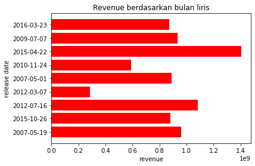

```python
df_cek=pd.DataFrame(drop_movies,columns=['release_date','revenue'])

indeks=np.array(df_cek['release_date'])

plt.barh(indeks[1:10],df["revenue"].iloc[1:10],color="r")
plt.title('Revenue berdasarkan bulan liris')
plt.xlabel('revenue')
plt.ylabel('release date')
```